# STA 141A Final Project

Keren Skariah

2025-03-17

# Predicting Decision Outcomes from Neural Activity in Mice

# Introduction

This analysis explores whether neural activity and visual stimuli can predict decision outcomes in mice. Understanding this relationship has broader implications for neuroscience, cognitive science, and even real-world applications like brain-computer interfaces and neuro-prosthetics. If neural signals reliably correlate with decision-making, it could deepen our understanding of how the brain processes sensory information and transforms it into actions.

The dataset, collected by Steinmetz et al. (2019), comes from experiments on 10 mice over 39 sessions. Each session involved hundreds of trials where mice viewed visual stimuli on two screens with varying contrast levels (0, 0.25, 0.5, 1) and used a wheel to indicate their decision. Their choices were followed by feedback—success (1) or failure (-1) and they were based on whether they responded correctly to the stimuli. Neural activity was recorded as spike trains, representing neuron firings, from the reveal of the stimuli to 0.4 seconds after. This analysis focuses on 18 sessions from four mice: Cori, Frossman, Hence, and Lederberg.

The key question driving this project is whether neural activity and stimulus contrast levels can predict the type of feedback the mice receive. If so, this could provide valuable insights into how sensory input influences decision-making at the neurological level. In the long term, research like this contributes to fields such as AI, where understanding biological decision-making can improve machine learning models, and medicine, where insights from neural activity could help develop treatments for cognitive disorders or enhance neuroprosthetic devices.

## Problem Setup

This project examines whether neural activity and visual stimuli can predict decision outcomes in mice. The goal is to analyze spike train data and contrast levels to determine their relationship with feedback type (success or failure).

## Source of Data

The dataset comes from Steinmetz et al. (2019), which recorded neural activity from mice performing a visual decision-making task. The study involved 10 mice across 39 sessions, but this analysis focuses on 18 sessions from four mice: Cori, Frossman, Hence, and Lederberg.

## Key Variables

- **Independent Variables**:
  - *contrast_left, contrast_right* – Contrast levels of stimuli (0, 0.25, 0.5, 1)
  - *brain_area* – Cortical region where spikes were recorded
- **Dependent Variable**:
  - *spike trains* – Neural firing activity (timestamped spike trains)
  - *feedback* – Success (1) or failure (-1) based on correctness of mouse’s decision

## Possible Hypotheses

1. Neural activity predicts *decision outcomes*
   - If certain patterns of neural firing are associated with correct / incorrect decisions, spike trains should be predictive of feedback type.
2. Stimulus contrast influences *decision accuracy*
   - Higher contrast differences between screens will lead to more correct choices, while lower contrasts will result in more random / incorrect decisions.
3. Brain regions contribute differently to *decision-making*
   - Some cortical areas may play a stronger role in processing visual input & guiding motor responses

Through testing these hypotheses, this study aims to provide insights into how sensory input / neural activity shape decision-making processes.

# Exploratory Data Analysis

## Descriptive Statistics

### Behavioral Data Analysis

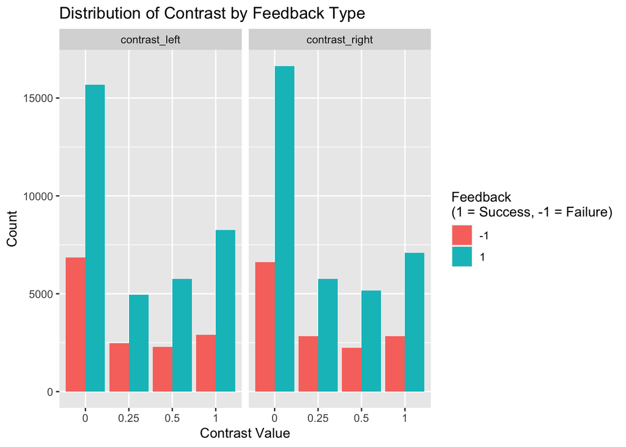

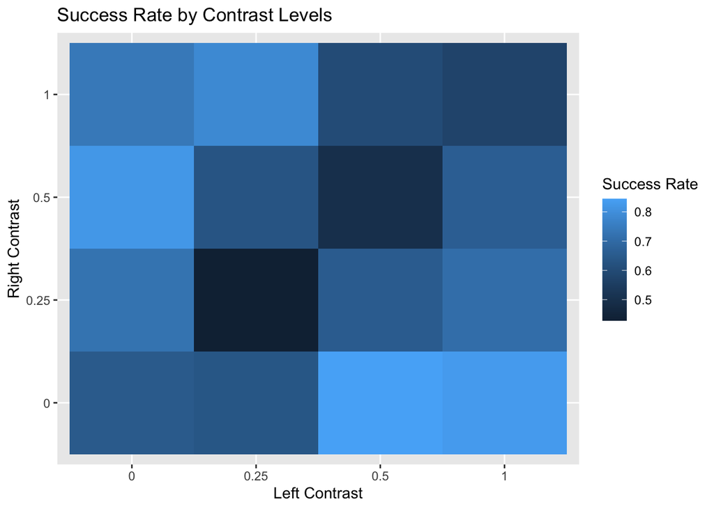

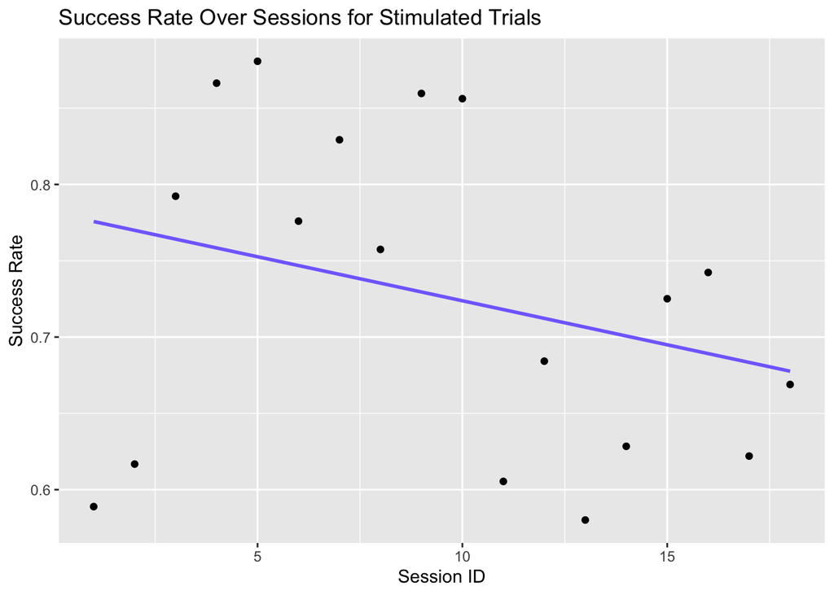

The linear trend in stimulated trials indicates that the success rate decreases over sessions. This suggests that the mice are showing signs of fatigue. As sessions progress, they become less proficient at processing the visual stimuli and executing the correct responses. In other words, repeated exposure to the task conditions seems to reduce their alertness and responsiveness, leading to worsened performance over time.

## Analyzing All Sessions

### Univariate Analysis: Feedback Type

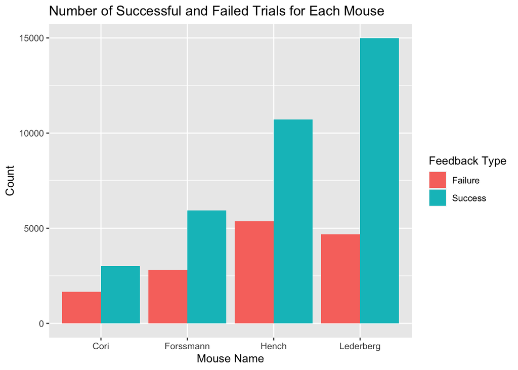

The bar plots reveal that while all four species exhibit more successful than failed trials, the magnitude of the success–failure gap varies noticeably by species. Specifically, Lederberg and Hench display a much larger gap (with Lederberg having the highest success rate), whereas Cori and Forssman show smaller gaps, with Cori having the lowest overall success rate. This naturally raises the question: Why do these species perform differently?

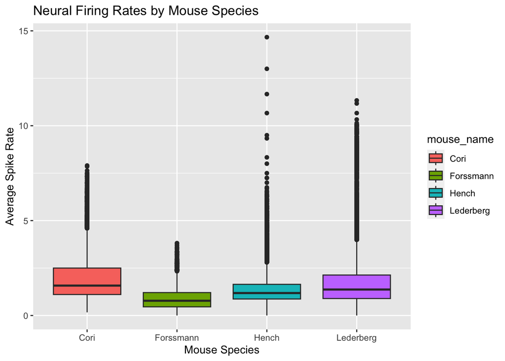

### Analysis of Neural Activity: Brain Area Distribution

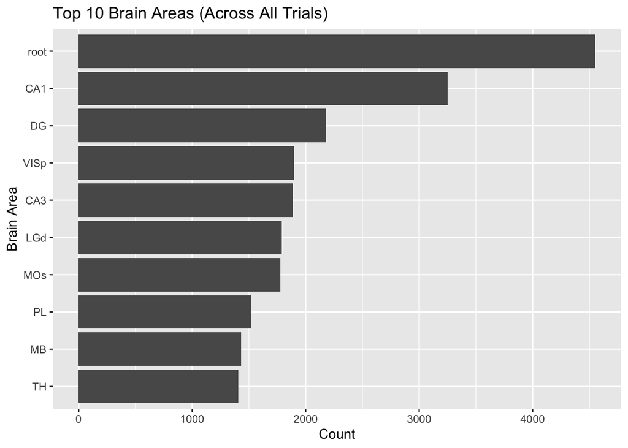

#### Interpretation:

**Hippocampal Involvement**: CA1, DG, and CA3 are all parts of the hippocampus, which is involved in learning / memory. Their presence suggests that the task may involve some learning or memory component (learning the association between the stimulus and the correct response).

**Visual and Motor Pathways**: The high counts for VISp, LGd, and MOs are expected, given the task. This confirms that the recordings are from brain areas relevant to the task.

**Higher-Order Cognitive Processes**: The presence of PL suggests involvement of prefrontal cortex, indicating that the task may involve decision-making processes beyond simple stimulus-response.

I hypothesize that activity in VISp, MOs, and the hippocampal regions (CA1, CA3, DG) will be significantly predictive of trial outcome. I hypothesize that activity in CA1, CA3, and DG will show changes over time that correlate with the mouse’s learning of the task.

### Analysis of Neural Activity: Average firing rates for each brain area

Based on my hypothesis that activity in CA1, CA3, and DG will show changes over time that correlate with the mouse’s learning of the task, I will create a plot.

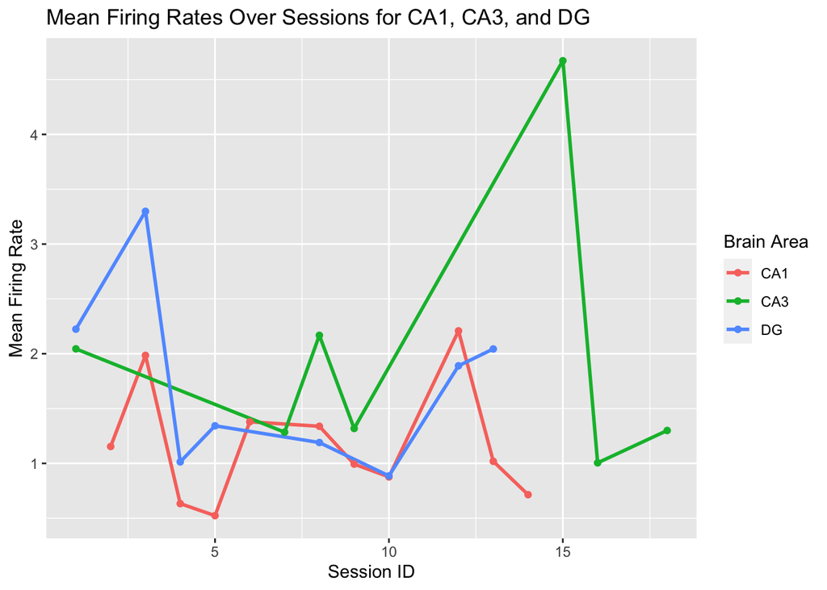

The three hippocampal regions show quite distinct patterns over sessions. The Dentate Gyrus (DG) exhibits a high level of activity in the early sessions—a sharp initial spike—but then declines and fails to reach the same peak in later sessions. This could suggest that DG is highly engaged during the initial exposure to the task, perhaps to facilitate early pattern separation or encoding of novel stimuli, but its role diminishes as the task becomes more familiar.

In contrast, CA1 maintains relatively consistent activity levels, with moderate fluctuations from session to session. This stability might indicate that CA1 serves as a reliable integrator of information throughout the learning process, reflecting a steady state of hippocampal output.

Meanwhile, CA3 demonstrates a volatile pattern: its activity fluctuates, culminating in a pronounced spike and jump at Session 15 followed by a dramatic drop. This surge could represent a transient phase where CA3 is intensely involved in associative processing or memory consolidation, after which its activity plummets—possibly reflecting a shift in neural strategy or synaptic reorganization as the mice consolidate their learning.

Overall, these patterns suggest that while all three regions are involved in the learning process, they may contribute in different ways. DG’s early high activity might be critical for initial learning and encoding, CA1’s steady output could reflect consistent processing of information, and CA3’s erratic behavior may point to its role in dynamic memory retrieval or network reorganization at key learning junctures.

### Time Series Analysis

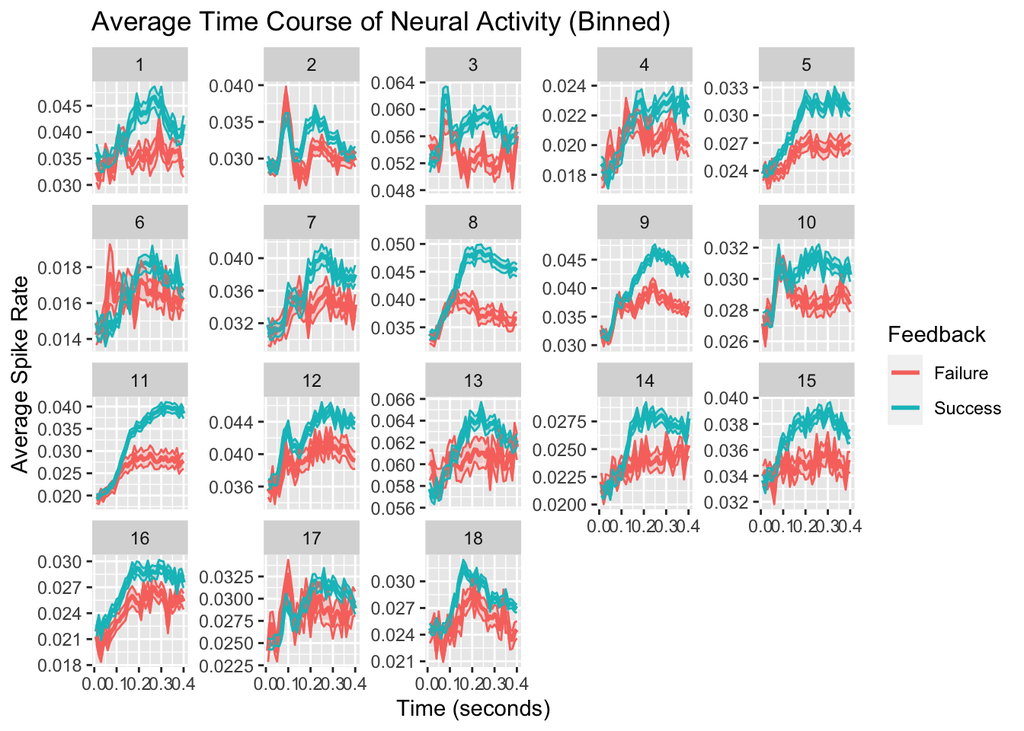

**Overall Shape**: In most of the graphs, the failure and successes have similar shapes, the successes. tend to just have a bit higher average spike rates. **Differences between Success and Failure**: In general, the successes seem to have higher peaks and consistently be larger than the failures. **Session-to-Session Consistency**: The time courses look similar across different sessions, with the average spike rates generally increasing, the rates just differ from time to time.

The plot indicates that while the basic timing of neural responses is consistent (indicating a common processing pathway), the amplitude of these responses is higher in successful trials. This supports the hypothesis that a more vigorous neural activation might underlie better performance on the task. The consistency across sessions further suggests that these patterns are robust and intrinsic to the task rather than being driven by random fluctuations or external factors.

### Session-to-Session Variability

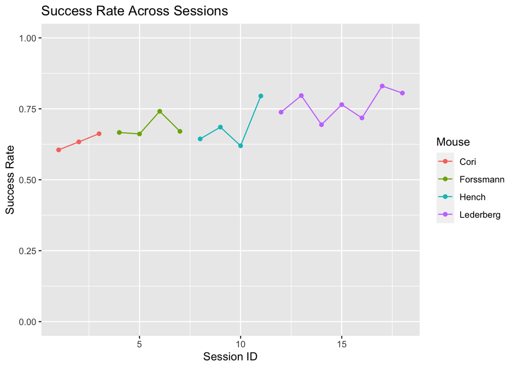

# Data Integration

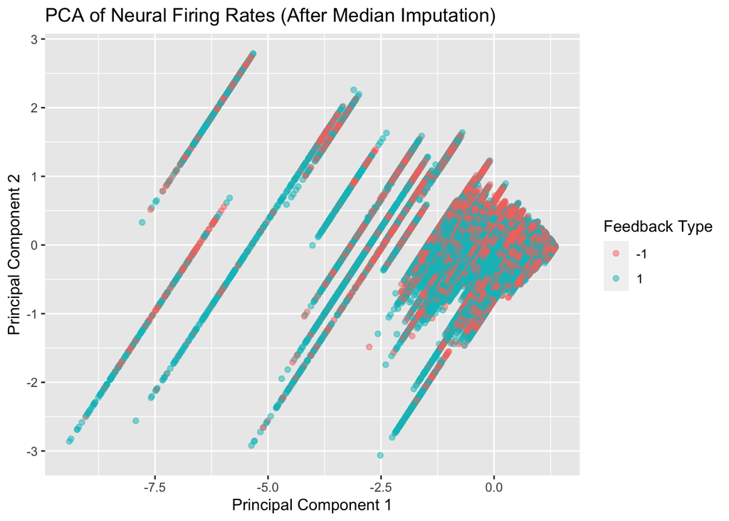

**Principal Component Analysis (PCA) Interpretation:** The PCA plot shows that trials labeled as success (1) and failure (-1) are largely interspersed across the first two principal components, indicating that these two dimensions do not strongly separate outcomes. This overlapping distribution suggests that:

*Dominant Sources of Variance*: The largest sources of variability in the neural firing rates (captured by PC1 and PC2) are driven by factors other than success vs. failure—potentially session differences, discrete firing patterns in certain brain areas, or other unaccounted variables.

*Potential Data Artifacts*: The “striping” along PC1 and PC2 indicates that the data may have discrete values or be heavily influenced by median imputation. Some brain areas might only be recorded in certain trials, creating chunks or stripes in the PCA space.

# Model Testing

I will now test different models to see which works best for this data. I will use the original neural features as the feature set.

The accuracy of *logistic regression* model is **0.7075**

The accuracy of *lasso* model is **0.7075**

The accuracy of *decision tree* model is **0.7075**

The accuracy of *gradient boost* model is **0.7075**

The accuracy of *k-Nearest Neighbors* model is **0.6881**

The fact that logistic regression, lasso, decision tree, and gradient boosting all reached an accuracy of 70.75% suggests that these models are capturing a similar underlying pattern in the data. They appear to be converging on a baseline level of predictive power with the current features. In contrast, k-nearest neighbor (KNN) achieved a slightly lower accuracy of 68.81%, which may be due to its sensitivity to local data structure and noise—especially in high-dimensional or less well-separated feature spaces. This could also indicate that the choice of distance metric or the number of neighbors in KNN is not optimal for the dataset. Overall, these results imply that the predictive signal in the features is modest, and simpler linear models (or models with similar decision boundaries) are sufficient, whereas KNN may be more adversely affected by the data’s characteristics.

## Test Data

Given the test data, it is time to find the accuracies with the new data.

The accuracy for *logistic regression* on the test data is **0.7256**

The accuracy for *lasso* on the test data is **0.7256**

The accuracy for *decision tree* on the test data is **0.7256**

The accuracy for *gradient boosting* on the test data is **0.7256**

The accuracy for *k-nearest* on the test data is **0.6978**

### Interpretation

These findings indicate that logistic regression, lasso, decision tree, and gradient boosting are all performing equally well on the test data, achieving an accuracy of 72.56%. This suggests that the underlying predictive signal in the neural features is captured similarly by these models—despite their differences in complexity—and that the relationships between the predictors and the outcome may be largely linear or straightforward.

In contrast, the k-nearest neighbors model, which relies on local distances, achieves a lower accuracy (69.78%). This means that k-nearest neighbors is more sensitive to the data’s local structure and noise, especially in a potentially high-dimensional feature space where distance metrics can become less informative.

Overall, these results imply that the current feature set provides a moderate predictive signal and that simpler, more interpretable models (like logistic regression) or those that capture non-linearity in a similar manner (like decision trees and gradient boosting) are preferable for this dataset.

# Conclusion

In this project, I integrated neural firing rate data and behavioral metrics across multiple sessions to explore whether neural activity can predict decision outcomes in mice. My analysis followed these key steps:

### Data Integration & EDA:

I processed and combined data from 18 sessions, creating a single comprehensive dataset. The exploratory analysis revealed that while the overall neural firing patterns were generally similar across trials, subtle differences emerged—especially when comparing trials with and without stimulus. This raised questions about whether the mice were learning or perhaps experiencing fatigue.

### PCA:

I applied principal component analysis on the neural features to visualize the data structure. Although the PCA plot did not reveal clearly separable clusters between successful and failed trials, it suggested that the major sources of variability in neural activity might be driven by factors other than trial outcome. This indicated that the predictive signal in the current features is modest.

### Model Testing:

I evaluated multiple predictive models using the original neural features, including logistic regression, lasso regression, decision trees, gradient boosting, and k-nearest neighbors. On the test data, logistic regression, lasso, decision tree, and gradient boosting all achieved an accuracy of 72.56%, while the k-nearest neighbors model reached 69.78%. These results suggest that the predictive signal in the dataset is relatively modest and that even simple linear models can capture the underlying relationship between neural activity and trial outcomes. The similar performance of these diverse models further implies that the relationship may be predominantly linear or that the current features capture a common baseline pattern. The slightly lower performance of k-nearest neighbors indicates that distance-based methods might be less effective in this context, possibly due to high-dimensional noise or subtle class boundaries.

## Final Thoughts and Next Steps

Interpretation: The overall performance of around 72.5% accuracy demonstrates that there is a moderate predictive signal in the neural data. However, the similar performance across different modeling approaches indicates that there is room for improvement. The absence of clear separation in the PCA plot suggests that additional feature engineering might help uncover more nuanced differences related to trial outcomes.

In summary, while the current analysis shows a moderate ability to predict decision outcomes based on neural activity, further refinement in data representation and model complexity may lead to improved performance and a deeper understanding of the neural mechanisms underlying decision-making in mice

# Acknowledgement

I used generative AI on this project to test out different models and see the accuracies. I also used it to debug and learn how to make models. I used gemini and chatgpt. Here is a link to a chat: https://chatgpt.com/share/67d8a986-5950-800c-9c6d-8cca29c6f253

Also, this was my first time ever doing a full data science project and report. This was a very interesting and informative experience. Thank you for making STA 141A a great learning experience! :)